# Motivation

This script is written to simulate the Monty Hall problem. For a more complete take, please see the wikipedia article or any books it refers to. https://en.wikipedia.org/wiki/Monty_Hall_problem

# The original problem

1. You pick one of three doors. Behind one of the doors is a car, behind the others a goat.
2. The show master opens one of the unchosen doors with a goat behind.
3. You have the chance to switch the door or stay

In all steps we assume by default that decisions are made uniformly random over the possible states of events.

# The assumptions

In the original problem the chance of winning if you always switch is 2/3, while if always staying is 1/3. These however comes with a few assumptions:

1. The host must always open a door that was not picked by the contestant.
2. The host must always open a door to reveal a goat and never the car.
3. The host must always offer the chance to switch between the originally chosen door and the remaining closed door.

There are also more obvious assumptions that are rather typical for game shows and thus typically presumed:

4. The car is placed randomly
5. The door is chosen randomly
6. The host (if possible) chooses the door to open randomly

# Simulation 1: Normal game

In the case of the normal game. The strategies *always switching* and *never switching* should be successfull in 2/3 and 1/3 of the cases, respectively.

## Function and variable definitions

```r
doors <- 1:3
carProb <- rep(1/3, 3)
ownProb <- rep(1/3, 3)
hostProb <- rep(1/2, 2)
switchProb <- c(1, 0) ## always stay
rounds <- 10000

play <- function(doors, carProb, ownProb, hostProb, switchProb) {
    car <- sample(doors, 1, prob = carProb)
    own <- sample(doors, 1, prob = ownProb)

    if(car == own) {
        host <- sample(doors[-car], 1, prob = hostProb)
    }
    else {
        host <- doors[-c(car, own)]
    }

    other <- doors[-c(own, host)]
    picked <- sample(c(own, other), 1, prob = switchProb)

    res <- ifelse(picked == car, 1, 0)
    return(res)
}
```

## Results

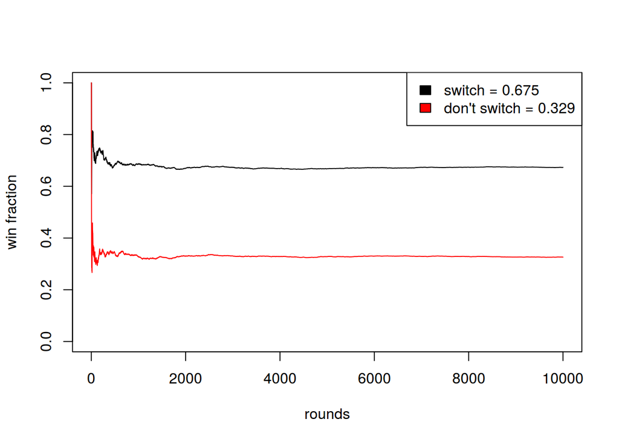

```r
alwaysSwitch <- sapply(1:rounds, function(x) {
    play(doors, carProb, ownProb, hostProb, switchProb = c(0,1))
})

neverSwitch <- sapply(1:rounds, function(x) {
    play(doors, carProb, ownProb, hostProb, switchProb)
})

switchPath <- cumsum(alwaysSwitch)/(1:length(alwaysSwitch))
noSwitchPath <- cumsum(neverSwitch)/(1:length(neverSwitch))
switchRes <- round(mean(switchPath), digits = 3)
noSwitchRes <- round(mean(noSwitchPath), digits = 3)

## plot results
plot(1:rounds, switchPath, type = "l", ylim = c(0, 1), xlab = "rounds", ylab = "win fraction")
lines(1:rounds, noSwitchPath, col = "red")
legend("topright", legend = c(paste("switch =", switchRes), paste("don't switch =", noSwitchRes)),
                              fill = c("black", "red"))
```

# Simulation 2: Conditional probability

The rather sloppy formulation of the question can be confusing in the sense that it might pose different questions and result in different answers. In the case of the above game the answer was given to the question of always switching vs. always staying *no matter what happens during the actual game*. That is we basically decide in advance. Computing the conditional probability in a certain situation does however result in a different outcome. For example given the choice of switching conditioned on the choice of door 1 and the host opened door two will result in a half-half probability of switching. That is because the host does not chose the door randomly anymore, but has a clear preference (stated by the condition).

## Function and variable definitions

Note the difference in the code to represent this situation. Now the conditions are established first and *then* the car gets placed. In the above game the car was placed in the very beginning. Thus resulting in a different situation, where the host has to pick a door *given* the car placement and the player’s door.

```r
doors <- 1:3
ownProb <- rep(1/3, 3)
switchProb <- c(1, 0) ## always stay
rounds <- 10000

play <- function(doors, ownProb, switchProb) {
    own <- sample(doors, 1, prob = ownProb)
    host <- doors[-own][1]

    other <- doors[-c(own, host)]
    picked <- sample(c(own, other), 1, prob = switchProb)

    car <- sample(doors[-host], 1)
    res <- ifelse(picked == car, 1, 0)
    return(res)
}
```

## Results

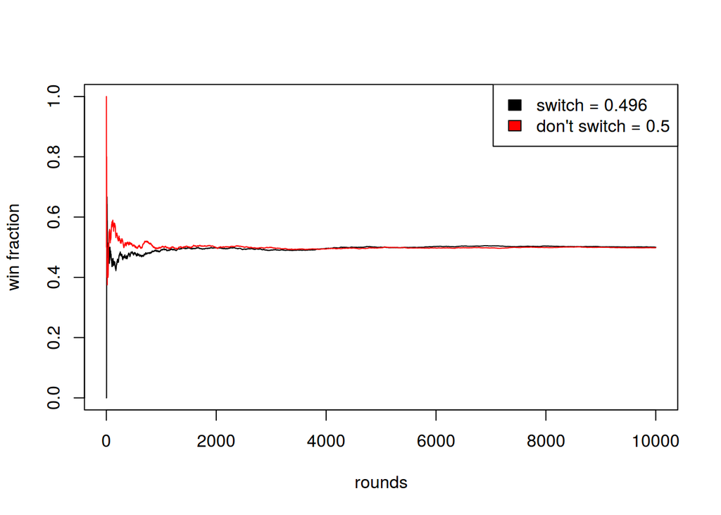

```r
alwaysSwitch <- sapply(1:rounds, function(x) {
    play(doors, ownProb, switchProb = c(0,1))
})

neverSwitch <- sapply(1:rounds, function(x) {
    play(doors, ownProb, switchProb)
})

switchPath <- cumsum(alwaysSwitch)/(1:length(alwaysSwitch))
noSwitchPath <- cumsum(neverSwitch)/(1:length(neverSwitch))
switchRes <- round(mean(switchPath), digits = 3)
noSwitchRes <- round(mean(noSwitchPath), digits = 3)

## plot results
plot(1:rounds, switchPath, type = "l", ylim = c(0, 1), xlab = "rounds", ylab = "win fraction")
lines(1:rounds, noSwitchPath, col = "red")
legend("topright", legend = c(paste("switch =", switchRes), paste("don't switch =", noSwitchRes)),
                              fill = c("black", "red"))
```